# Confidence Interval for a Population Mean

Yuanting Lu

03/31/2023

In the previous two sections, we worked with categorical variables (e.g., in favor/not in favor, smoker/nonsmoker, defective component/good component), for which we learned how to

- Predict (i.e., confidence interval) an unknown true proportion of a particular category in the population.
- Test (i.e., hypothesis testing) an unknown true proportion of a particular category in the population.

Now, we turn to numerical variables. Our objectives remain the same.

- Predicting (i.e., confidence interval) an unknown population mean (this section).
- Testing (i.e., hypothesis testing) an unknown population mean (next section).

### Notations

Let’s start with a review of the notations.

- $\mu$: the population mean
- $\sigma$: the population standard deviation
- $\overline{x}$: a sample mean
- $s$: a sample standard deviation
- $n$: sample size
- $z_\alpha$: a $z$-score in a standard normal distribution whose right tail has a size of $\alpha$. For example, $z_{0.01}=2.326$. We can find it by `qnorm(0.99)`, because this is the 99<sup>th</sup> percentile (i.e., only 1% data is above this number). As we have learned before, $z_{0.01}$ is the $z$-score we need for a 98% confidence interval, $z_{0.025}$ is the $z$-score we need for a 95% confidence interval, and so on.

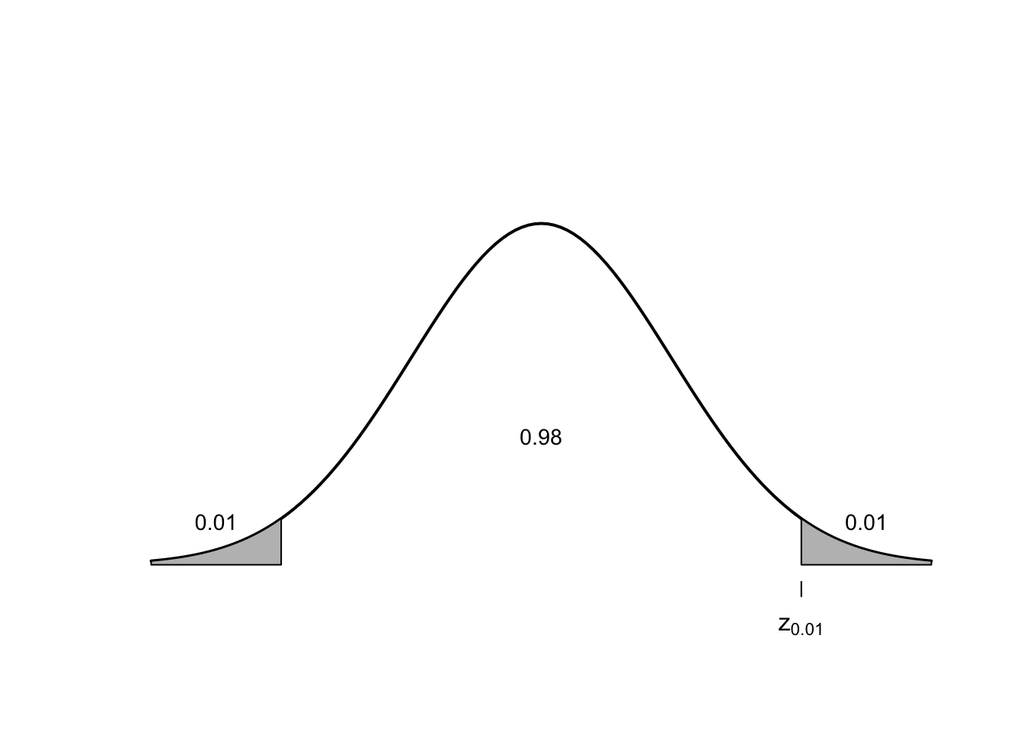

### Interval Estimator

#### With Known $\sigma$

If the population standard deviation, $\sigma$, is known, a confidence interval for a population mean $\mu$ is
$$\left(\overline{x} -
z_{\alpha}\dfrac{\sigma}{\sqrt n}, \quad\overline{x} +
z_{\alpha}\dfrac{\sigma}{\sqrt n}\right).$$

**Book Example 8.5 and 8.6** Suppose that if a signal having intensity $\mu$ originates at location A, then the intensity recorded at location B is normally distributed with mean $\mu$ and standard deviation 3. That is, due to “noise,” the intensity recorded typically differs from the actual intensity of the signal. To reduce the error, the same signal is independently recorded 10 times. If the successive recorded values are
$$17, 21,
20, 18, 19, 22, 20, 21, 16, 19.$$

1. Construct a 90% confidence interval for $\mu$, the actual intensity.
- Plug in the following numbers to the formula:
  - $\overline{x}=19.3, \sigma=3$.
  - $z_{0.05}=1.645$ `qnorm(0.95)`
- We are 90% confident that the true intensity of the original signal is between 17.74 and 20.86.
2. Construct a 95% confidence interval for $\mu$, the actual intensity.
- Same formula as in (a), except this time we use $z_{0.025}=1.96$ `qnorm(0.975)`
- We are 95% confident that the true intensity of the original signal is between 17.44 and 21.16.
3. Construct a 99% confidence interval for $\mu$, the actual intensity.
- Same formula as in (a) and (b), except this time we use $z_{0.005}=2.576$ `qnorm(0.995)`
- We are 99% confident that the true intensity of the original signal is between 16.86 and 21.74.
4. Compare the three intervals, which one has the smallest margin of error?
- The margin of error for the three intervals are 1.56, 1.86, and 2.44, respectively. So the 90% interval has the smallest margin of error among the three (i.e., the most accurate).However, it also has the lowest confidence level among the three. So, this shows the trade off between accuracy and confidence.

#### With Unknown $\sigma$

If the population standard deviation, $\sigma$, is unknown, a confidence interval for a population mean $\mu$ is
$$\left(\overline{x} - t_{\alpha}\dfrac{s}{\sqrt
n}, \quad\overline{x} + t_{\alpha}\dfrac{s}{\sqrt
n}\right).$$

What differences have you noticed between the two formulas (known $\sigma$ vs unknown $\sigma$)?

- When the population standard deviation $\sigma$ is unknown, we use the sample standard deviation $s$ to replace it in the formula.
- As a result, we need to adjust the probability model from a standard normal distribution ($z_\alpha$) to t-distribution ($t_{\alpha}$). Below is a comparison of the standard normal distribution (red curve) with a t-distribution whose degree of freedom is 10 (df=10, black curve).

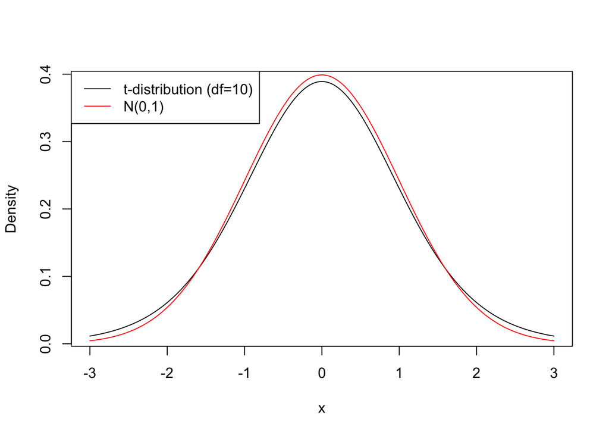

*T-distribution* Any t-distribution has a bell-shaped curve centered at 0 similar to the standard normal distribution. However, it has fatter tails. Therefore, compare to the standard normal distribution, t-distribution has a greater chance to include extreme values in the tails. Since we don’t know about the population standard deviation, we would like to prepare for the possiblity of more extreme values in the tails, thus the change from standard normal distribution to t-distributions.

T-distribution has a parameter called the *degree of freedom*, which equals the sample size minus 1. So, the degree of freedom for a sample of size 20 will be 19.

The table below compares the R commands for the t-distribution with the standard normal distribution. As you can see the only difference is that we have to plug in a degree of freedom (df) for the t-distribution.

|  | T-distribution | Standard Normal Distribution |
| --- | --- | --- |
| Probability | `pt(t, df)` | `pnorm(z)` |
| Percentile | `qt(p, df)` | `qnorm(p)` |

**Example** Find the 99<sup>th</sup> percentile in a t-distribution with a degree of freedom 10.

Use `qt(0.99, 10)` to see $t_{0.01}=2.764$. (We denote it by $t_{0.01}$ because there is 1% data above this number in the distribution.)

**Book Example 8.13** The Environmental Protection Agency (EPA) is concerned about the amounts of PCB, a toxic chemical, in the milk of nursing mothers. In a sample of 20 women, the amounts (in parts per million) of PCB were as follows:
$$16, 0, 0, 2, 3, 6, 8, 2, 5, 0, 12, 10, 5, 7, 2,
3, 8, 17, 9, 1$$
Use these data to obtain a

1. 95% confidence interval of the average amount of PCB in the milk of nursing mothers.
- Plug in the following numbers to the formula:
  - $\overline{x}=5.8, s=5.085$.
  - $t_{0.025}=2.093$ `qt(0.975, 19)` when the degree of freedom is 19 (sample size minus 1).
- We are 95% confident that the true amount of PCB in the milk of nursing mothers is between 3.42 ppm and 8.18 ppm.
2. 99% confidence interval of the average amount of PCB in the milk of nursing mothers.
- Same as (a), except $t_{0.005}=2.861$ `qt(0.995, 19)` when the degree of freedom is 19 (sample size minus 1).
- We are 99% confident that the true amount of PCB in the milk of nursing mothers is between 2.55 ppm and 9.05 ppm. We lose accuracy as we increase the confidence level.